# Homework 3

Lev Mazaev

October 22, 2019

Let’s load the data file.

```r
load(file = 'GSE23878_norm.dat')
```

We have to extract expression matrix and metadata for each sample/feature.

```r
m <- Biobase::exprs(eset) # expression matrix
md <- Biobase::pData(eset) # metadata for each sample
fd <- Biobase::fData(eset) # metadata for each feature (gene)
nrow(m); ncol(m); nrow(md); ncol(md)
```

```
## [1] 20183
```

```
## [1] 58
```

```
## [1] 58
```

```
## [1] 32
```

Let’s see if the expression data is normalized.

```r
colSums(m)
```

```
## GSM588828 GSM588829 GSM588830 GSM588831 GSM588832 GSM588833 GSM588834
##  95354.95  95354.95  95354.95  95354.95  95354.95  95354.95  95354.95
## GSM588835 GSM588836 GSM588837 GSM588838 GSM588839 GSM588840 GSM588841
##  95354.95  95354.95  95354.95  95354.95  95354.95  95354.95  95354.95
## GSM588842 GSM588843 GSM588844 GSM588845 GSM588846 GSM588847 GSM588848
##  95354.95  95354.95  95354.95  95354.95  95354.95  95354.95  95354.95
## GSM588849 GSM588850 GSM588851 GSM588852 GSM588853 GSM588854 GSM588855
##  95354.95  95354.95  95354.95  95354.95  95354.95  95354.95  95354.95
## GSM588856 GSM588857 GSM588859 GSM588860 GSM588861 GSM588862 GSM588863
##  95354.95  95354.95  95354.95  95354.95  95354.95  95354.95  95354.95
## GSM588864 GSM588865 GSM588866 GSM588867 GSM588868 GSM588869 GSM588870
##  95354.95  95354.95  95354.95  95354.95  95354.95  95354.95  95354.95
## GSM588871 GSM588872 GSM588873 GSM588874 GSM588875 GSM588876 GSM588877
##  95354.95  95354.95  95354.95  95354.95  95354.95  95354.95  95354.95
## GSM588878 GSM588879 GSM588880 GSM588881 GSM588882 GSM588883 GSM588884
##  95354.95  95354.95  95354.95  95354.95  95354.95  95354.95  95354.95
## GSM588885 GSM588886
##  95354.95  95354.95
```

At least the sum along each column is the same. What would show the boxplots?

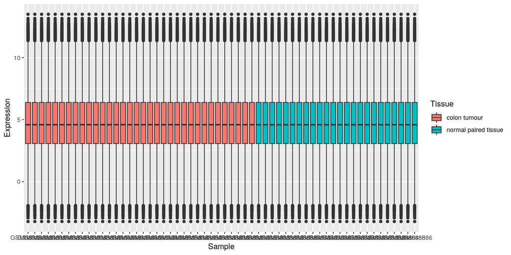

```r
mt <- as_tibble(m)
mt$gene <- rownames(m)
mt <- mt %>% pivot_longer(cols = starts_with('GSM'),
                   names_to = 'Sample',
                   values_to = 'Expression')
mt <- mt %>% left_join(y = md[, c(2, 8)], by =c('Sample' = 'geo_accession' ))
colnames(mt)[4] <- 'Tissue'
ggplot(data = mt, mapping = aes(x = Sample, y = Expression,
                                fill = Tissue)) +
  geom_boxplot()
```

Here are 58 boxplots, one for each sample. As we can see they all are well aligned, so the normalization is OK.

Next we have to find genes differentially expressed between tissue types. In order to see something let’s do the PCA at first.

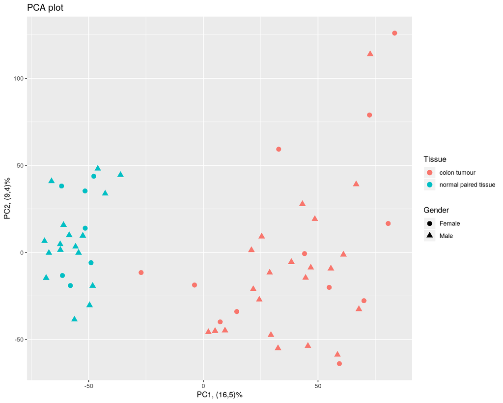

```r
pca <- prcomp(t(m), scale. = FALSE)
pv <- round(100 * pca$sdev^2 / sum(pca$sdev^2), 1)
data_pca <- tibble(PC1 = pca$x[, 1], PC2 = pca$x[, 2],
                   Tissue = md$source_name_ch1,
                   Gender = md$`gender:ch1`)
ggplot(data = data_pca, mapping = aes(x = PC1, y = PC2,
                                      color = Tissue, shape = Gender)) +
  geom_point(size = 3) + ggtitle('PCA plot') +
  xlab(paste0('PC1, (', pv[1], ')%')) +
  ylab(paste0('PC2, (', pv[2], ')%'))
```

It’s obvious that differential expression between the tissue types is the dominant source of variation. Gender is just for joke, it definitely does not convey any message. Let’s see if we need to filter some probes (genes).

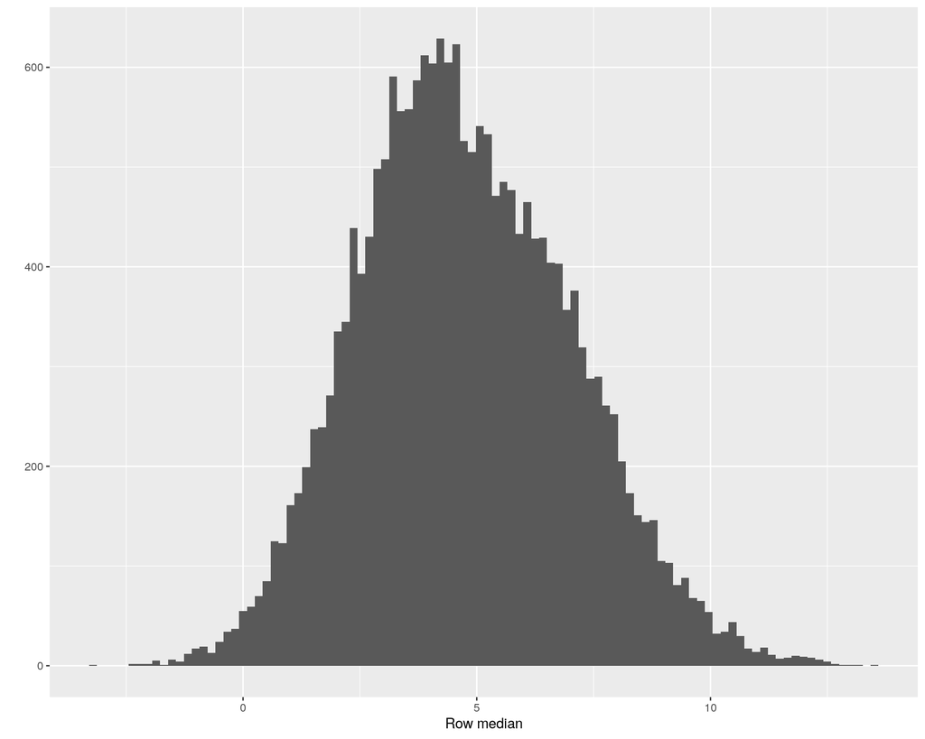

```r
row_meds <- Biobase::rowMedians(m)
qplot(row_meds, bins = 100, xlab = 'Row median')
```

I think we don’t need any filtering. Now let’s use GLM with negative-binomial family to find some differentially expressed genes (I used *limma* at first, but it strangely categorized all genes as DE).

```r
library(MASS)
glm.control(maxit = 100)
```

```
## $epsilon
## [1] 1e-08
##
## $maxit
## [1] 100
##
## $trace
## [1] FALSE
```

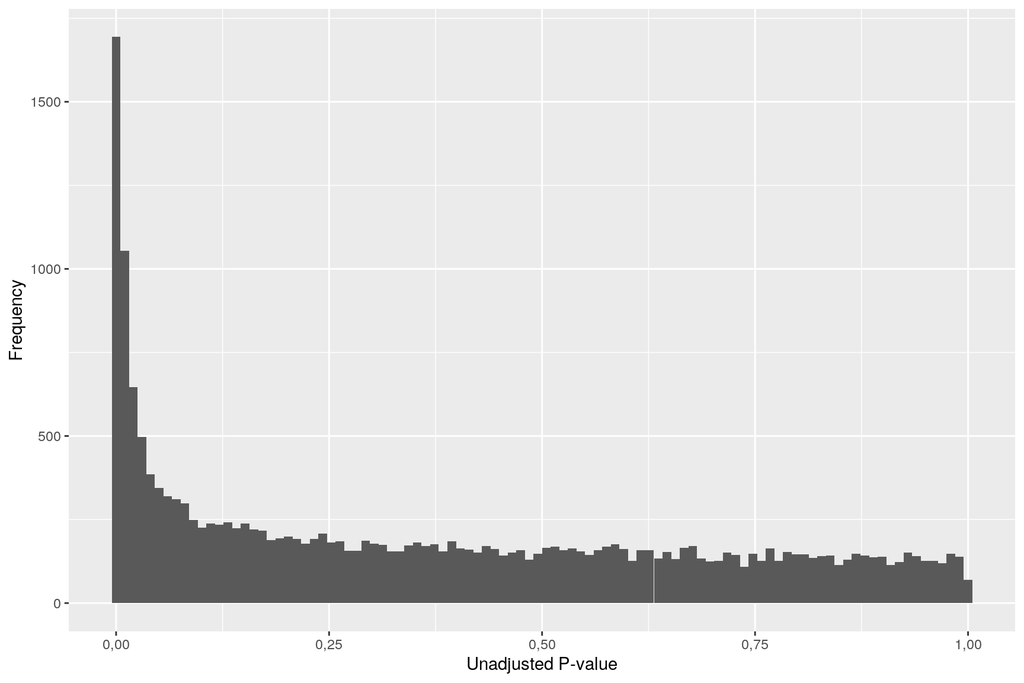

```r
transM <- as_tibble(t(m))
tum <- startsWith(as.vector(md$source_name_ch1), 'colon')
pvals <- sapply(transM, function(x) return(anova(glm.nb(tum ~ x))$`Pr(>Chi)`[2]))
qplot(pvals, xlab = 'Unadjusted P-value', ylab = 'Frequency', bins = 100)
```

top10 genes:

```r
head(fd$`Gene Symbol`[order(pvals)], n = 10)
```

```
##  [1] "CDH3"  "ETV4"  "LGI1"  "ESM1"  "PLP1"  "FOXQ1" "CEMIP" "EPHX4"
##  [9] "MYOT"  "CA7"
```

Now let’s adjust p-values for multiple hypothesis testing.

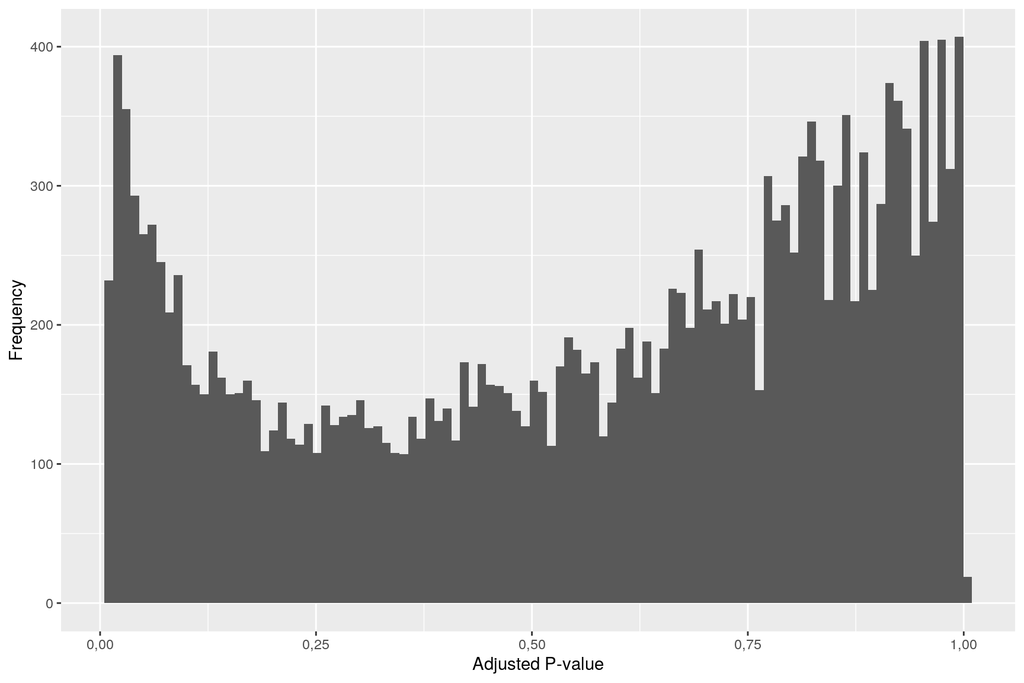

```r
apvals <- p.adjust(pvals, method = 'BH')
qplot(apvals, xlab = 'Adjusted P-value', ylab = 'Frequency', bins = 100)
```

```r
alpha <- 0.05
```

Number of genes passing the threshold $FDR < 0.05$ is 1421. Top 10 according to adjusted p-values:

```r
head(fd$`Gene Symbol`[order(apvals)], n = 10)
```

```
##  [1] "CDH3"   "ETV4"   "LGI1"   "ESM1"   "PLP1"   "EPHX4"  "MAMDC2"
##  [8] "HILPDA" "CEMIP"  "CA7"
```

```r
geneList <- tibble(
  ProbeID = fd$ID,
  GeneSymbol = fd$`Gene Symbol`,
  EntrezID = fd$ENTREZ_GENE_ID,
  Pvalue = pvals,
  AdjPvalue = apvals
)
siGenes <- geneList[geneList$AdjPvalue < alpha, ]
knitr::kable(head(arrange(siGenes, AdjPvalue), n=10))
```

| ProbeID | GeneSymbol | EntrezID | Pvalue | AdjPvalue |
| --- | --- | --- | --- | --- |
| 203256_at | CDH3 | 1001 | 3,0e-07 | 0,0054964 |
| 211603_s_at | ETV4 | 2118 | 8,0e-07 | 0,0058503 |
| 206349_at | LGI1 | 9211 | 9,0e-07 | 0,0058503 |
| 208394_x_at | ESM1 | 11082 | 1,2e-06 | 0,0062634 |
| 210198_s_at | PLP1 | 5354 | 1,6e-06 | 0,0063831 |
| 239579_at | EPHX4 | 253152 | 3,5e-06 | 0,0079901 |
| 228885_at | MAMDC2 | 256691 | 4,4e-06 | 0,0079901 |
| 218507_at | HILPDA | 29923 | 4,8e-06 | 0,0079901 |
| 212942_s_at | CEMIP | 57214 | 3,3e-06 | 0,0079901 |
| 207504_at | CA7 | 766 | 4,3e-06 | 0,0079901 |

Performing enrichment analysis.

```r
library(topGO)
gl <- apvals
names(gl) <- fd$ENTREZ_GENE_ID
setGO <- new('topGOdata', description = 'new session', ontology = 'BP',
             allGenes = gl, geneSel = function(x) return(x < alpha),
             nodeSize = 10,
             annot = annFUN.org,
             mapping = 'org.Hs.eg.db',
             ID = 'entrez')
# 3 different test
resultKS.elim <- runTest(setGO, algorithm = 'elim', statistic = 'ks')
resultKS.classic <- runTest(setGO, algorithm = 'classic', statistic = 'ks')
resultFisher <- runTest(setGO, algorithm = "classic", statistic = "fisher")
```

```r
goEnrichment <- GenTable(setGO, KS=resultKS.classic, orderBy = 'KS',
                         topNodes = 20)
knitr::kable(goEnrichment)
```

| GO.ID | Term | Annotated | Significant | Expected | KS |
| --- | --- | --- | --- | --- | --- |
| GO:0042254 | ribosome biogenesis | 189 | 37 | 15,96 | 2,3e-10 |
| GO:0022613 | ribonucleoprotein complex biogenesis | 320 | 51 | 27,02 | 4,4e-09 |
| GO:1903047 | mitotic cell cycle process | 744 | 125 | 62,83 | 1,3e-08 |
| GO:0034660 | ncRNA metabolic process | 437 | 70 | 36,90 | 1,5e-08 |
| GO:0051301 | cell division | 545 | 100 | 46,02 | 1,5e-08 |
| GO:0007049 | cell cycle | 1585 | 204 | 133,84 | 1,9e-08 |
| GO:0006364 | rRNA processing | 142 | 30 | 11,99 | 2,5e-08 |
| GO:0016072 | rRNA metabolic process | 176 | 36 | 14,86 | 2,6e-08 |
| GO:0000278 | mitotic cell cycle | 854 | 133 | 72,11 | 2,7e-08 |
| GO:0008283 | cell proliferation | 1755 | 200 | 148,20 | 6,1e-08 |
| GO:0071840 | cellular component organization or bioge… | 5505 | 518 | 464,86 | 6,4e-08 |
| GO:0044770 | cell cycle phase transition | 548 | 93 | 46,27 | 6,9e-08 |
| GO:0034470 | ncRNA processing | 273 | 51 | 23,05 | 1,7e-07 |
| GO:0022402 | cell cycle process | 1178 | 165 | 99,47 | 2,8e-07 |
| GO:0006259 | DNA metabolic process | 893 | 114 | 75,41 | 5,4e-07 |
| GO:0033554 | cellular response to stress | 1774 | 177 | 149,80 | 7,3e-07 |
| GO:0006260 | DNA replication | 247 | 44 | 20,86 | 9,0e-07 |
| GO:0006261 | DNA-dependent DNA replication | 123 | 28 | 10,39 | 1,1e-06 |
| GO:0044772 | mitotic cell cycle phase transition | 508 | 91 | 42,90 | 1,2e-06 |
| GO:0000070 | mitotic sister chromatid segregation | 128 | 34 | 10,81 | 1,5e-06 |

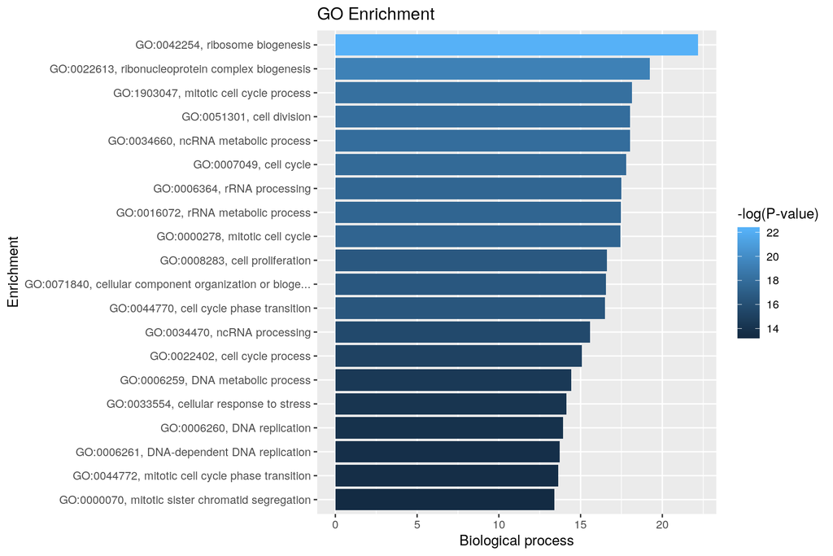

```r
goEnrichment$ExtTerm <- paste(goEnrichment$GO.ID, goEnrichment$Term, sep = ', ')
goEnrichment$KS <- as.numeric(gsub(',', '.', goEnrichment$KS))
ggplot(data = goEnrichment, aes(x = reorder(ExtTerm, -KS), y = -log(KS))) +
  geom_col(aes(fill = -log(KS))) + coord_flip() +
  scale_fill_gradient() +
  xlab('Enrichment') +
  ylab('Biological process') +
  ggtitle('GO Enrichment') +
  labs(fill = '-log(P-value)')
```

Overrepresentation analysis.

Let’s filted filter out small (<10) gene sets. Also let’s remove all genes not represented in at least one gene set. In parallel I’m doing overrepresentation analysis using WebGestalt (using **affy hg u133 plus 2**). Later I’ll compare it with manual Fisher Test.

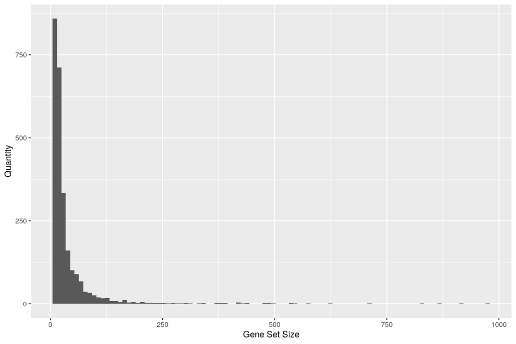

```r
interest <- siGenes$EntrezID
geneSets <- annFUN.org("BP", mapping = "org.Hs.eg.db", ID = "entrez")
geneSets <- geneSets[lengths(geneSets) >= 10]
genePool <- purrr::reduce(geneSets, union)
interest <- interest[interest %in% genePool]
noninterest <- genePool[!genePool %in% interest]
qplot(lengths(geneSets), bins = 100, xlab = 'Gene Set Size', ylab = 'Quantity')
```

```r
write.table(interest, 'genes.txt', quote = FALSE, row.names = FALSE, col.names = FALSE)
```

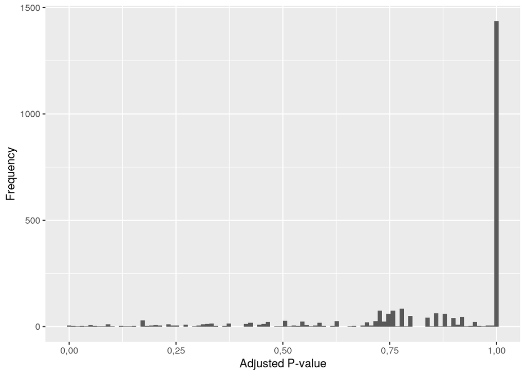

```r
fpvals <- sapply(geneSets, function(gs) {
  gs <- unlist(gs)
  a11 <- length(intersect(interest, gs))
  a12 <- length(setdiff(interest, gs))
  a21 <- length(intersect(noninterest, gs))
  a22 <- length(setdiff(noninterest, gs))
  # print(cbind(c(a11, a21), c(a12, a22)))
  return(fisher.test(cbind(c(a11, a21), c(a12, a22)), alternative = 'greater')$p.value)
})
afpvals <- p.adjust(fpvals, method = 'BH')
qplot(afpvals, xlab = 'Adjusted P-value', ylab = 'Frequency', bins = 100)
```

```r
localFisherGS <- names(afpvals[afpvals < alpha])
webGestalt <- read.table(file = 'enrichment_results_wg_result1572007005.txt',
                         header = TRUE, sep = '\t')
webGestaltGS <- webGestalt$geneSet
ksGS <- goEnrichment$GO.ID
```

Let’s draw Venn diagram.

```r
library(VennDiagram)
venn.diagram(
  x = list(localFisherGS, webGestaltGS, ksGS),
  category.names = c('Manual Fisher Test',
                     'WebGestalt Service',
                     'KS Test from TopGO'),
  filename = 'venn.png',
  output = TRUE,
          imagetype="png",
          height = 800,
          width = 800,
          resolution = 300,
          compression = "lzw",
          lwd = 1,
          col=c("#440154ff", '#21908dff', '#fde725ff'),
          fill = c(alpha("#440154ff",0.3), alpha('#21908dff',0.3), alpha('#fde725ff',0.3)),
          cex = 0.5,
          fontfamily = "sans",
          cat.cex = 0.3,
          cat.default.pos = "outer",
          cat.pos = c(-27, 27, 135),
          cat.dist = c(0.055, 0.055, 0.085),
          cat.fontfamily = "sans",
          cat.col = c("#440154ff", '#21908dff', '#fde725ff'),
          rotation = 1
)
```

```
## [1] 1
```

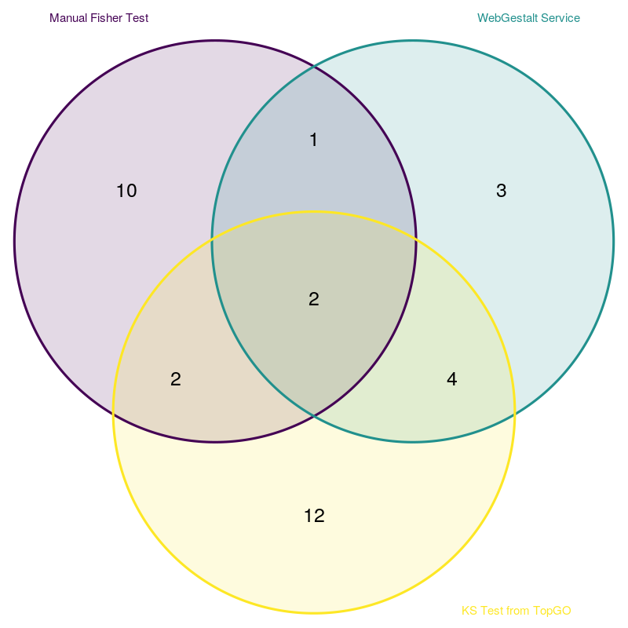

```r
knitr::include_graphics('venn.png')
```

And one more pic.

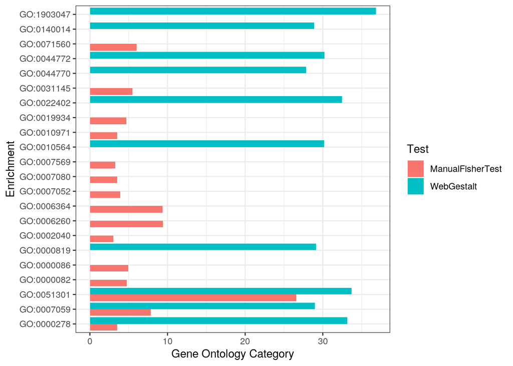

```r
my_set <- tibble(
  GO_ID = names(afpvals[afpvals < alpha]),
  ManualFisherTest = afpvals[afpvals < alpha]
)
wg <- tibble(
  GO_ID = as.vector(webGestalt$geneSet),
  WebGestalt = webGestalt$pValue + 1e-16,
)
df <- my_set %>% full_join(wg, by = 'GO_ID')
df <- df %>% pivot_longer(cols = 2:3, names_to = 'Test', values_to = 'Pval')
ggplot(df, mapping = aes(x = reorder(GO_ID, -log(Pval)), y = -log(Pval), fill = Test)) +
  geom_col(position = 'dodge', na.rm = TRUE) + coord_flip() +
  xlab('Enrichment') + ylab('Gene Ontology Category') +
  theme_bw()
```